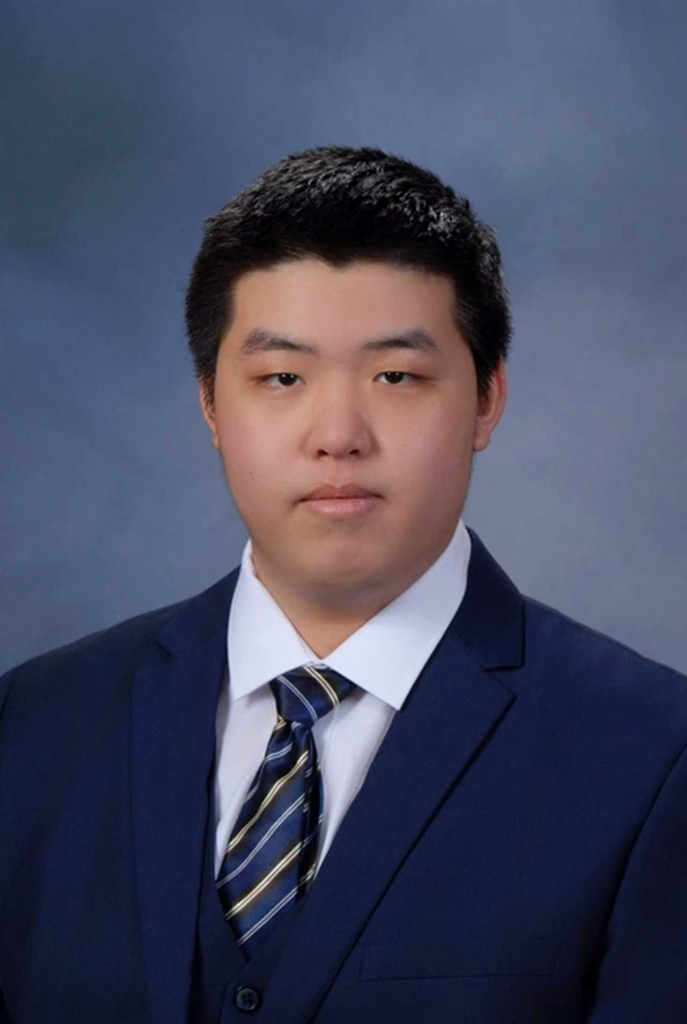

# Fuxin Chai

## Bio

Hi, I’m Fuxin Chai. I am currently an ScM student in Biostatistics at Johns Hopkins University. I am interested in both statistics and biology, and I am currently exploring different research areas to find what I would like to focus on in the future.

One reason I am particularly interested in the connection between these fields is that many cellular processes depend on molecular concentrations, diffusion, and stochastic interactions. I believe statistical methods can provide a useful way to understand the variability and complexity of biological systems.

## Education

**Johns Hopkins University**  
ScM in Biostatistics | September 2026 – Present

**Michigan State University**  
Bachelor’s Degree in Statistics | September 2022 - May 2026

## Research Interests

My current research interests include genomics, genetics, neuroimaging, computational biology, and systems biology. I am currently exploring these areas and hope to develop a clearer research focus as I gain more experience.

## Goals for This Course

My goal for this course is to review programming methods that I have learned and to develop new skills. In particular, I hope to learn more about Positron and to learn how to create and publish websites as part of a reproducible statistical computing workflow.